# Limpieza y ordenamiento de datos

Felipe Calvo Cepeda - fcalvoc@unal.edu.co | Universidad Nacional de Colombia

2021

## Algunos enfoques teóricos para modelar y analizar datos

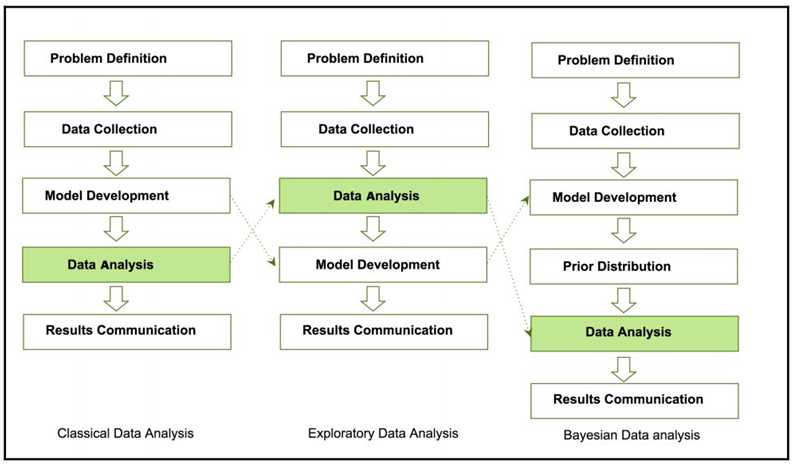

## Algunos enfoques prácticos para modelar y analizar datos

> **KDD**: Knowledge Discovery in Databases

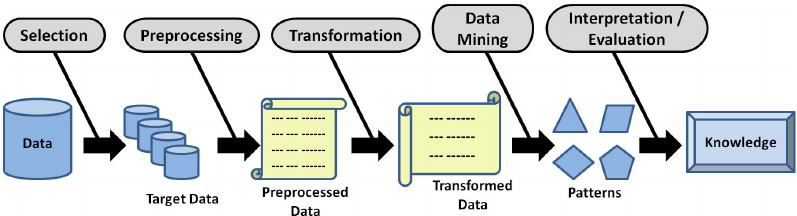

> **SEMMA**: Sample, Explore, Modify, Model, and Assess

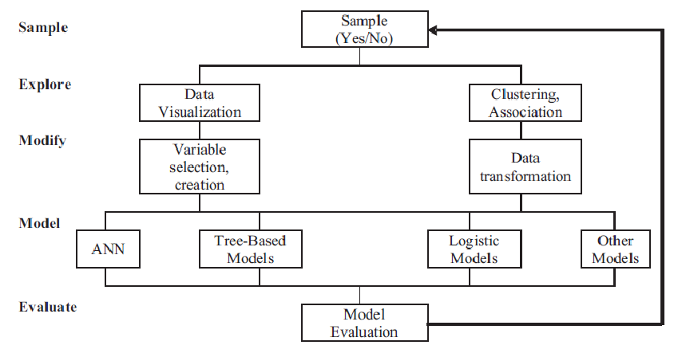

> **CRISP-DM**: Cross Industry Standard Process for Data Mining

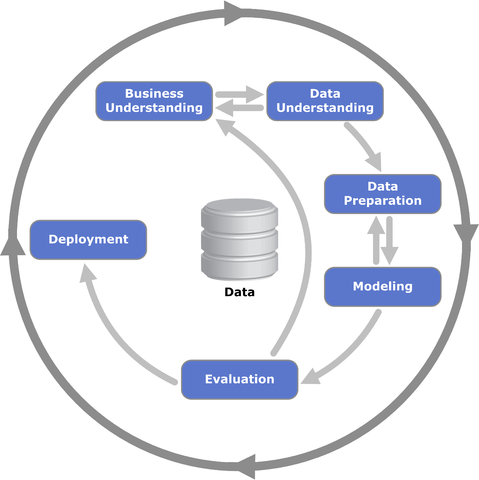

## Desde el punto de vista computacional

> ETL
- **Extract**: Es el proceso de lectura de datos de diversas fuentes.
- **Transform**: Es el proceso de limpieza de datos para su posterior inserción en un data warehouse.
- **Load**: Es el proceso de inserción de datos al data warehouse.

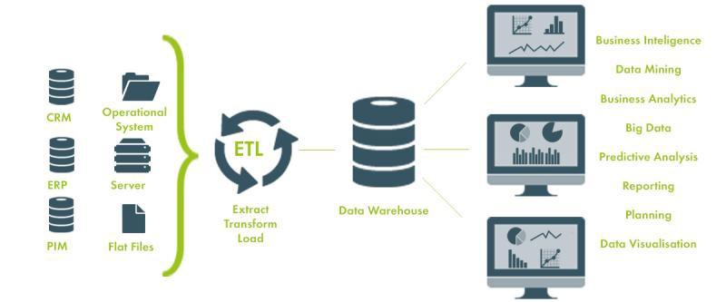

## La limpieza de datos es un paso/subproceso necesario

Dos tendencias relevantes:

1. El 80% de la ciencia de datos tiene que ver con tener datos y tenerlos bien estructurados y limpios. La industria necesita reducir esos tiempos para que los científicos de datos le dediquen más tiempo a los procesos de análisis.
2. De acuerdo con IBM, se espera que para el 2022 los procesos automatizados de preparación de datos sean usados en el 70% de nuevos proyectos.

## ¿Qué hemos dicho sobre la limpieza de datos?

Implica observar más de cerca los problemas en los datos que ha seleccionado incluir en el análisis.

| Problema de datos | Solución posible |
| --- | --- |
| Datos perdidos | Estimar e imputar el dato. Excluir las filas o características. |
| Datos atípicos | Mantenerlos. Excluir las filas o características. |
| Errores de codificación | Adoptar un esquema de codificación simple y convertir y sustirur los valores o nombres de variables. |
| Datos duplicados* | Buscar y eliminar duplicados. |

## ¿Qué mas podemos hacer?

- **Estructurado**
- **Enriquecimiento**
- **Combinación de conjuntos de datos**

Ejemplo: ¿Cuál tabla es mejor?

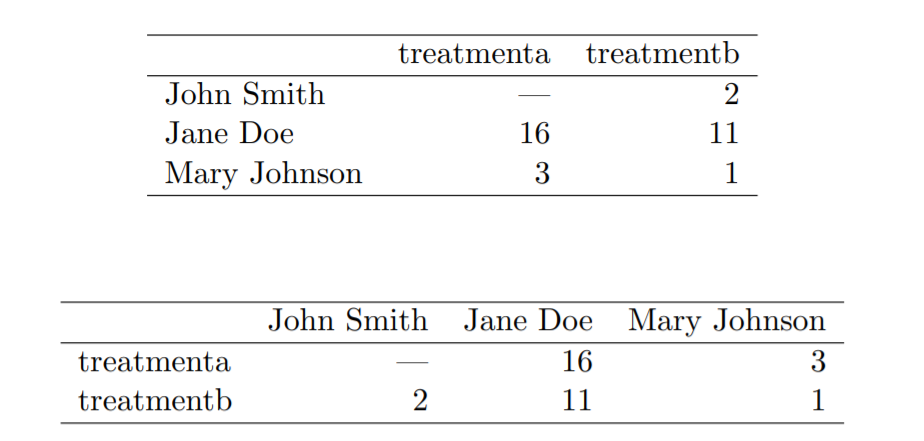

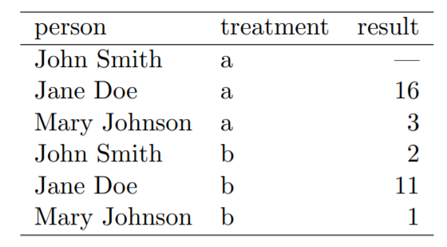

## Principios básicos de organización de datos tabulares

1. Cada variable forma una columna
2. Cada observación forma una fila
3. Cada tipo de unidad observacional forma una tabla
4. Las tablas deben tener un encabezado con un nombre o códificación adecuado
5. Nunca almacenar más de una misma variable en una celda

## 9+1 consejos de Google para limpiar datos

1. Usa Formularios para introducir datos automáticamente
2. Restringe la introducción de datos con listas
3. Valida las direcciones de correo electrónico
4. Combina datos de varias hojas de cálculo en una sola
5. Busca y actualiza los datos
6. Divide los datos en columnas
7. De ser necesario, intercambia datos de filas y columnas
8. Elimina los datos duplicados
9. Elimina los espacios adicionales
10. Automatizar (scripting) la limpieza de datos.

## Ejercicio de aplicación #1

Revise de manera individual cada una de las bases de datos de referencia, e indique si cada una tiene una estructura adecuada para ser trabajada a través de herramientas como

- CCB
- DPS
- CPC
- MEN

## Ejercicio de aplicación #2

- [Construcción colaborativa de un flujograma de limpieza de datos](https://jamboard.google.com/d/1aphMPVlU7oCIKeab_vbrijhZ1X_ttP8P7nZWXCrpsn4/edit?usp=sharing)

## Ejercicio de aplicación #3

- [Codificación del flujograma en Google Colab - Python](https://colab.research.google.com/drive/15-FGU0stnJQYe9aeg5BIF5EuANSRKx5o?usp=sharing)
- [Codificación del flujograma en Google Colab - R](https://colab.research.google.com/drive/1BLH5FrGG_cFgiIqD8eDSM7ysYGP27ov7?usp=sharing)